# Project 2 - Data Tidying and Transformation

Author

Yeimi Perez

Published

October 8, 2026

# Approach

For Project 2, I will work with three separate wide-format datasets selected from the Week 5 Discussion 5A options. My goal will be to preserve each dataset in its original wide format first and then use R, mainly the tidyr and dplyr packages, to transform each dataset into a tidy format that is easier to analyze. For each dataset, I will examine the original structure, identify the columns that need to be reorganized, rename variables when necessary, and address missing or inconsistent values. I will document the transformation process so that each step can be reproduced from the original raw data.

Some challenges I expect include determining the correct variables to keep as identifiers, deciding which columns should be pivoted from wide to long format, and handling missing or inconsistently formatted values without losing important information. I will use summary tables and visualizations when appropriate and will explain the results for each dataset in context.

# Introduction

The purpose of this project is to practice cleaning, tidying, transforming, and analyzing three different wide-format datasets. The datasets include U.S. average tuition by state, population estimates for the ten most populous U.S. states, and World Bank life expectancy data. Although the datasets cover different topics, each provides an opportunity to transform data from a wide structure into a tidy format that is easier to analyze.

For each dataset, I will first examine the original structure, then use functions from tidyr and dplyr to reshape and clean the data. After the transformation is complete, I will use the tidy data to create summary statistics and visualizations. This process demonstrates how data preparation can make different types of datasets more useful for analysis.

```r
library(tidyverse)
library(readr)
```

## Dataset 1 | U.S. Average Tuition

```r
tuition_url <- "https://raw.githubusercontent.com/yeimiperez14/Data_607/refs/heads/main/Project%202/us_avg_tuition(Table%205).csv"

tuition_raw <- read_csv(tuition_url)
```

The first dataset contains average tuition information for U.S. states across multiple academic years. The original dataset was obtained from other student, Mubin Ejaz, on 5A discussion and was saved as a CSV file on my github in its original wide format: [https://github.com/yeimiperez14/Data_607/tree/main/Project%202.](https://github.com/yeimiperez14/Data_607/tree/main/Project%202)

### Data structure before Tidying

```r
dim(tuition_raw)
```

```
[1] 50 13
```

```r
names(tuition_raw)
```

```
 [1] "State"   "2004-05" "2005-06" "2006-07" "2007-08" "2008-09" "2009-10"
 [8] "2010-11" "2011-12" "2012-13" "2013-14" "2014-15" "2015-16"
```

```r
glimpse(tuition_raw)
```

```
Rows: 50
Columns: 13
$ State     <chr> "Alabama", "Alaska", "Arizona", "Arkansas", "California", "C…
$ `2004-05` <chr> "$5,683", "$4,328", "$5,138", "$5,772", "$5,286", "$4,704", …
$ `2005-06` <chr> "$5,841", "$4,633", "$5,416", "$6,082", "$5,528", "$5,407", …
$ `2006-07` <chr> "$5,753", "$4,919", "$5,481", "$6,232", "$5,335", "$5,596", …
$ `2007-08` <chr> "$6,008", "$5,070", "$5,682", "$6,415", "$5,672", "$6,227", …
$ `2008-09` <chr> "$6,475", "$5,075", "$6,058", "$6,417", "$5,898", "$6,284", …
$ `2009-10` <chr> "$7,189", "$5,455", "$7,263", "$6,627", "$7,259", "$6,948", …
$ `2010-11` <chr> "$8,071", "$5,759", "$8,840", "$6,901", "$8,194", "$7,748", …
$ `2011-12` <chr> "$8,452", "$5,762", "$9,967", "$7,029", "$9,436", "$8,316", …
$ `2012-13` <chr> "$9,098", "$6,026", "$10,134", "$7,287", "$9,361", "$8,793",…
$ `2013-14` <chr> "$9,359", "$6,012", "$10,296", "$7,408", "$9,274", "$9,293",…
$ `2014-15` <chr> "$9,496", "$6,149", "$10,414", "$7,606", "$9,187", "$9,299",…
$ `2015-16` <chr> "$9,751", "$6,571", "$10,646", "$7,867", "$9,270", "$9,748",…
```

We have 50 rows and 13 columns. Each row represents a state, while each academic year is stored in a separate column. The dataset is therefore in wide format because academic year is represented across multiple columns instead of being stored as one variable. The tuition columns were also imported as character values and will need to be converted to numeric values before analysis.

### Transformation steps

```r
tuition_long <- tuition_raw %>%
  pivot_longer(
    cols = -State,
    names_to = "academic_year",
    values_to = "tuition"
  )

head(tuition_long)
```

```
# A tibble: 6 × 3
  State   academic_year tuition
  <chr>   <chr>         <chr>
1 Alabama 2004-05       $5,683
2 Alabama 2005-06       $5,841
3 Alabama 2006-07       $5,753
4 Alabama 2007-08       $6,008
5 Alabama 2008-09       $6,475
6 Alabama 2009-10       $7,189
```

I transformed every column except state and placed the old year column names and corresponding tuition amount into one variable.

### Cleaning the variables

```r
tuition_tidy <- tuition_long %>% rename( state = State ) %>% mutate( tuition = parse_number(tuition) )
```

Tuition was imported as character/text. We need numeric values before calculating means.

### Addressing missing values

```r
colSums(is.na(tuition_tidy))
```

```
        state academic_year       tuition
            0             0             0
```

No missing values were identified, so no observations needed to be removed.

### Analysis

```r
tuition_summary <- tuition_tidy %>%
  group_by(academic_year) %>%
  summarise(
    average_tuition = mean(tuition, na.rm = TRUE)
  )

tuition_summary
```

```
# A tibble: 12 × 2
   academic_year average_tuition
   <chr>                   <dbl>
 1 2004-05                 6410.
 2 2005-06                 6654.
 3 2006-07                 6810.
 4 2007-08                 7086.
 5 2008-09                 7157.
 6 2009-10                 7762.
 7 2010-11                 8229.
 8 2011-12                 8539.
 9 2012-13                 8842.
10 2013-14                 8948.
11 2014-15                 9037.
12 2015-16                 9318.
```

`group_by(academic_year)` organizes the observations by year, `summarise()` creates one result for each academic year, `mean()` calculates average tuition across states and `na.rm = TRUE` prevents missing tuition values from breaking the calculation.

### Visualization

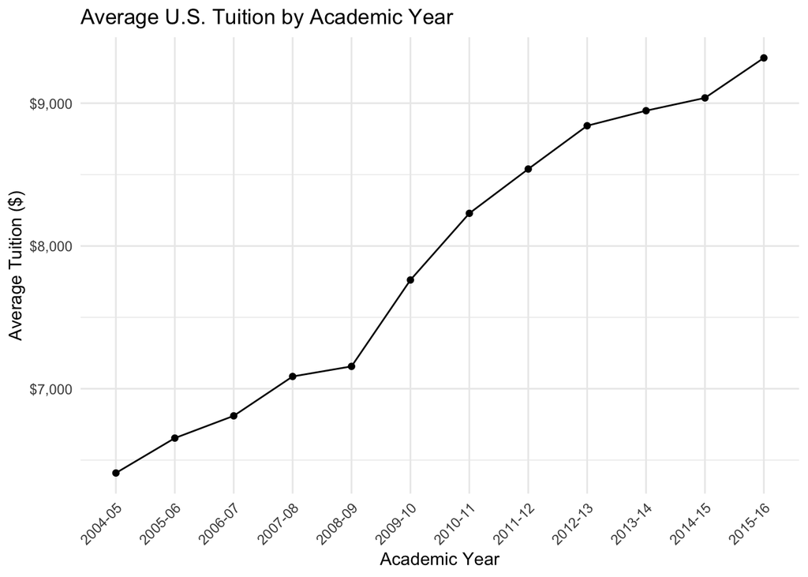

```r
ggplot(
  tuition_summary,
  aes(
    x = academic_year,
    y = average_tuition,
    group = 1
  )
) +
  geom_line() +
  geom_point() +
  labs(
    title = "Average U.S. Tuition by Academic Year",
    x = "Academic Year",
    y = "Average Tuition ($)"
  ) +
  scale_y_continuous(
    labels = scales::dollar_format()
  ) +
  theme_minimal() +
  theme(
    axis.text.x = element_text(
      angle = 45,
      hjust = 1
    )
  )
```

### Interpretation

```r
highest_tuition <- tuition_tidy %>%
  arrange(desc(tuition)) %>%
  select(state, academic_year, tuition) %>%
  slice(1)

highest_tuition
```

```
# A tibble: 1 × 3
  state         academic_year tuition
  <chr>         <chr>           <dbl>
1 New Hampshire 2012-13         15224
```

```r
tuition_change <- tuition_tidy %>%
  group_by(state) %>%
  summarise(
    starting_tuition = first(tuition),
    ending_tuition = last(tuition),
    tuition_change = ending_tuition - starting_tuition
  )

tuition_change
```

```
# A tibble: 50 × 4
   state       starting_tuition ending_tuition tuition_change
   <chr>                  <dbl>          <dbl>          <dbl>
 1 Alabama                 5683           9751           4068
 2 Alaska                  4328           6571           2243
 3 Arizona                 5138          10646           5508
 4 Arkansas                5772           7867           2095
 5 California              5286           9270           3984
 6 Colorado                4704           9748           5044
 7 Connecticut             7984          11397           3413
 8 Delaware                8353          11676           3323
 9 Florida                 3848           6360           2512
10 Georgia                 4298           8447           4149
# ℹ 40 more rows
```

### Classifying the direction of change

```r
tuition_change <- tuition_change %>%
  mutate(
    trend = case_when(
      tuition_change > 0 ~ "Lower to Higher",
      tuition_change < 0 ~ "Higher to Lower",
      TRUE ~ "No Change"
    )
  )

tuition_change
```

```
# A tibble: 50 × 5
   state       starting_tuition ending_tuition tuition_change trend
   <chr>                  <dbl>          <dbl>          <dbl> <chr>
 1 Alabama                 5683           9751           4068 Lower to Higher
 2 Alaska                  4328           6571           2243 Lower to Higher
 3 Arizona                 5138          10646           5508 Lower to Higher
 4 Arkansas                5772           7867           2095 Lower to Higher
 5 California              5286           9270           3984 Lower to Higher
 6 Colorado                4704           9748           5044 Lower to Higher
 7 Connecticut             7984          11397           3413 Lower to Higher
 8 Delaware                8353          11676           3323 Lower to Higher
 9 Florida                 3848           6360           2512 Lower to Higher
10 Georgia                 4298           8447           4149 Lower to Higher
# ℹ 40 more rows
```

### Which state increased the most

```r
tuition_change %>%
  arrange(desc(tuition_change)) %>%
  head(10)
```

```
# A tibble: 10 × 5
   state         starting_tuition ending_tuition tuition_change trend
   <chr>                    <dbl>          <dbl>          <dbl> <chr>
 1 Hawaii                    4267          10175           5908 Lower to Higher
 2 Arizona                   5138          10646           5508 Lower to Higher
 3 Colorado                  4704           9748           5044 Lower to Higher
 4 Illinois                  8183          13189           5006 Lower to Higher
 5 New Hampshire            10188          15160           4972 Lower to Higher
 6 Virginia                  7030          11819           4789 Lower to Higher
 7 Georgia                   4298           8447           4149 Lower to Higher
 8 Washington                6192          10288           4096 Lower to Higher
 9 Alabama                   5683           9751           4068 Lower to Higher
10 Michigan                  7931          11991           4060 Lower to Higher
```

### Which one decreased the most

```r
tuition_change %>%
  filter(tuition_change < 0) %>%
  arrange(tuition_change)
```

```
# A tibble: 1 × 5
  state starting_tuition ending_tuition tuition_change trend
  <chr>            <dbl>          <dbl>          <dbl> <chr>
1 Ohio             10378          10196           -182 Higher to Lower
```

```r
tuition_change %>%
  count(trend)
```

```
# A tibble: 2 × 2
  trend               n
  <chr>           <int>
1 Higher to Lower     1
2 Lower to Higher    49
```

### Visualization

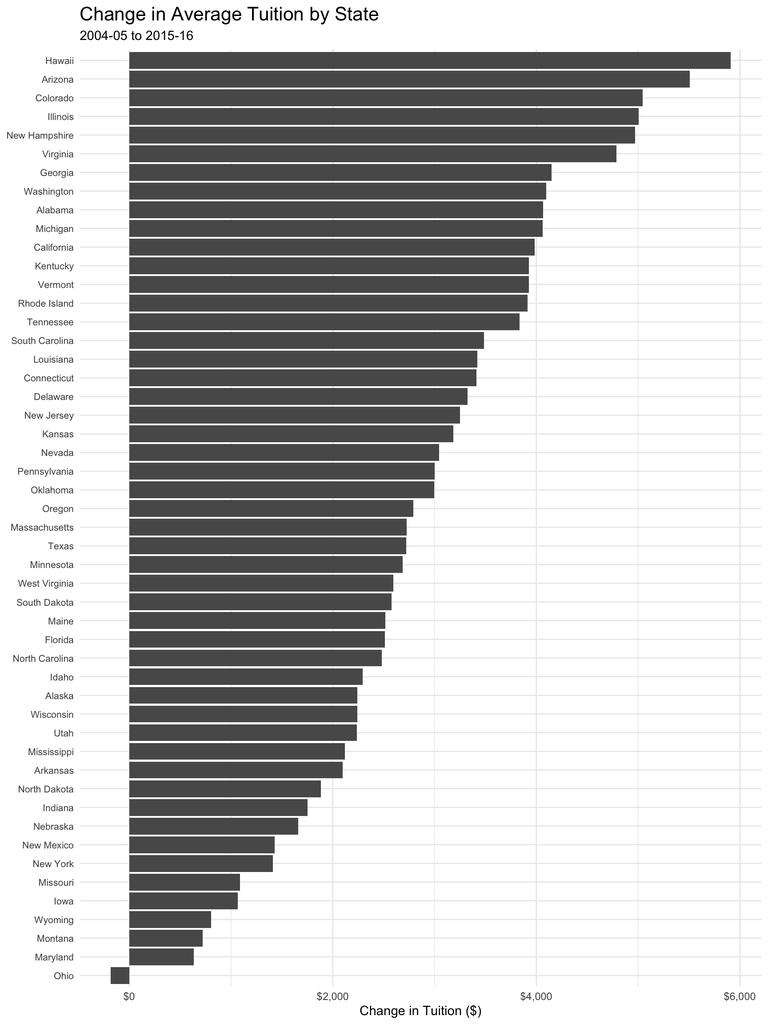

```r
ggplot(
  tuition_change,
  aes(
    x = tuition_change,
    y = reorder(state, tuition_change)
  )
) +
  geom_col() +
  scale_x_continuous(
    labels = scales::dollar_format()
  ) +
  labs(
    title = "Change in Average Tuition by State",
    subtitle = "2004-05 to 2015-16",
    x = "Change in Tuition ($)",
    y = NULL
  ) +
  theme_minimal() +
  theme(
    axis.text.y = element_text(size = 8),
    plot.title = element_text(size = 16),
    plot.subtitle = element_text(size = 11)
  )
```

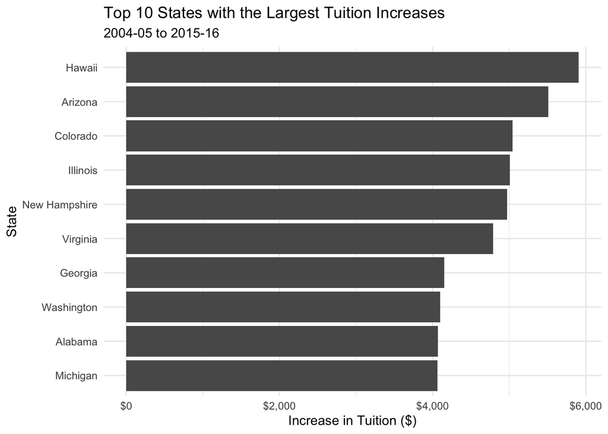

```r
top_10_tuition_change <- tuition_change %>%
  arrange(desc(tuition_change)) %>%
  slice_head(n = 10)

ggplot(
  top_10_tuition_change,
  aes(
    x = tuition_change,
    y = reorder(state, tuition_change)
  )
) +
  geom_col() +
  scale_x_continuous(
    labels = scales::dollar_format()
  ) +
  labs(
    title = "Top 10 States with the Largest Tuition Increases",
    subtitle = "2004-05 to 2015-16",
    x = "Increase in Tuition ($)",
    y = "State"
  ) +
  theme_minimal()
```

This part sorts the states by `tuition_change` and keeps only the 10 largest increases. The graph then compares those 10 states rather than trying to squeeze all 50 state names into one figure.

### Interpretation

The results show that tuition increased substantially in several states between 2004–05 and 2015–16. Hawaii had the largest increase, rising from **$4,267 to $10,175**, an increase of **$5,908**. Arizona had the second-largest increase at **$5,508**, followed by Colorado at **$5,044** and Illinois at **$5,006**. All 10 states with the largest changes showed a lower-to-higher tuition trend over the period.

## Dataset 2 | Census top 10 States

```r
population_url <- "https://raw.githubusercontent.com/yeimiperez14/Data_607/refs/heads/main/Project%202/census_top10_states_2022_untidy.csv"

population_raw <- read_csv(population_url)
```

This dataset contains population estimates for the 10 most populous U.S. states. It includes each state’s rank and geographic area, along with population estimates for April 1, 2020, July 1, 2021, and July 1, 2022. The population dates are stored in separate columns, making this a wide-format dataset that can be transformed into a tidy long format for analysis. The original dataset was obtained from other student, Anastasia Gmyrina, on 5A discussion and was saved as a CSV file on my github in its original wide format: [https://github.com/yeimiperez14/Data_607/tree/main/Project%202.](https://github.com/yeimiperez14/Data_607/tree/main/Project%202)

### Data structure before tidying

```r
dim(population_raw)
```

```
[1] 10  5
```

```r
names(population_raw)
```

```
[1] "Rank"                           "Geographic Area"
[3] "April 1, 2020 (Estimates Base)" "July 1, 2021"
[5] "July 1, 2022"
```

```r
head(population_raw)
```

```
# A tibble: 6 × 5
   Rank `Geographic Area` April 1, 2020 (Estimat…¹ `July 1, 2021` `July 1, 2022`
  <dbl> <chr>                                <dbl>          <dbl>          <dbl>
1     1 California                        39538245       39142991       39029342
2     2 Texas                             29145428       29558864       30029572
3     3 Florida                           21538226       21828069       22244823
4     4 New York                          20201230       19857492       19677151
5     5 Pennsylvania                      13002689       13012059       12972008
6     6 Illinois                          12812545       12686469       12582032
# ℹ abbreviated name: ¹`April 1, 2020 (Estimates Base)`
```

```r
glimpse(population_raw)
```

```
Rows: 10
Columns: 5
$ Rank                             <dbl> 1, 2, 3, 4, 5, 6, 7, 8, 9, 10
$ `Geographic Area`                <chr> "California", "Texas", "Florida", "Ne…
$ `April 1, 2020 (Estimates Base)` <dbl> 39538245, 29145428, 21538226, 2020123…
$ `July 1, 2021`                   <dbl> 39142991, 29558864, 21828069, 1985749…
$ `July 1, 2022`                   <dbl> 39029342, 30029572, 22244823, 1967715…
```

```r
names(population_raw)
```

```
[1] "Rank"                           "Geographic Area"
[3] "April 1, 2020 (Estimates Base)" "July 1, 2021"
[5] "July 1, 2022"
```

### Transformation steps

```r
population_long <- population_raw %>%
  pivot_longer(
    cols = c(
      `April 1, 2020 (Estimates Base)`,
      `July 1, 2021`,
      `July 1, 2022`
    ),
    names_to = "population_date",
    values_to = "population"
  )

head(population_long)
```

```
# A tibble: 6 × 4
   Rank `Geographic Area` population_date                population
  <dbl> <chr>             <chr>                               <dbl>
1     1 California        April 1, 2020 (Estimates Base)   39538245
2     1 California        July 1, 2021                     39142991
3     1 California        July 1, 2022                     39029342
4     2 Texas             April 1, 2020 (Estimates Base)   29145428
5     2 Texas             July 1, 2021                     29558864
6     2 Texas             July 1, 2022                     30029572
```

Before, one state occupied one row, with three different population columns. After `pivot_longer()`, each state will have three rows

I stored population as a number.

```r
population_tidy <- population_long %>%
  rename(
    rank = Rank,
    state = `Geographic Area`
  )

names(population_tidy)
```

```
[1] "rank"            "state"           "population_date" "population"
```

```r
population_tidy <- population_tidy %>%
  mutate(
    population = parse_number(as.character(population))
  )
```

```r
glimpse(population_tidy)
```

```
Rows: 30
Columns: 4
$ rank            <dbl> 1, 1, 1, 2, 2, 2, 3, 3, 3, 4, 4, 4, 5, 5, 5, 6, 6, 6, …
$ state           <chr> "California", "California", "California", "Texas", "Te…
$ population_date <chr> "April 1, 2020 (Estimates Base)", "July 1, 2021", "Jul…
$ population      <dbl> 39538245, 39142991, 39029342, 29145428, 29558864, 3002…
```

```r
head(population_tidy)
```

```
# A tibble: 6 × 4
   rank state      population_date                population
  <dbl> <chr>      <chr>                               <dbl>
1     1 California April 1, 2020 (Estimates Base)   39538245
2     1 California July 1, 2021                     39142991
3     1 California July 1, 2022                     39029342
4     2 Texas      April 1, 2020 (Estimates Base)   29145428
5     2 Texas      July 1, 2021                     29558864
6     2 Texas      July 1, 2022                     30029572
```

### Addressing missing values

```r
colSums(is.na(population_tidy))
```

```
           rank           state population_date      population
              0               0               0               0
```

No missing values identified.

### Analysis

```r
population_change <- population_tidy %>%
  filter(
    population_date %in% c(
      "April 1, 2020 (Estimates Base)",
      "July 1, 2022"
    )
  ) %>%
  select(state, population_date, population) %>%
  pivot_wider(
    names_from = population_date,
    values_from = population
  )

population_change
```

```
# A tibble: 10 × 3
   state          `April 1, 2020 (Estimates Base)` `July 1, 2022`
   <chr>                                     <dbl>          <dbl>
 1 California                             39538245       39029342
 2 Texas                                  29145428       30029572
 3 Florida                                21538226       22244823
 4 New York                               20201230       19677151
 5 Pennsylvania                           13002689       12972008
 6 Illinois                               12812545       12582032
 7 Ohio                                   11799374       11756058
 8 Georgia                                10711937       10912876
 9 North Carolina                         10439414       10698973
10 Michigan                               10077325       10034113
```

I compared each state’s 2020 population estimate with its 2022 population estimate. I calculated both the numerical change and the percentage change to determine which states gained or lost population.

```r
population_change <- population_change %>%
  mutate(
    population_change =
      `July 1, 2022` - `April 1, 2020 (Estimates Base)`,

    percent_change =
      (population_change / `April 1, 2020 (Estimates Base)`) * 100
  )

population_change
```

```
# A tibble: 10 × 5
   state  April 1, 2020 (Estim…¹ `July 1, 2022` population_change percent_change
   <chr>                   <dbl>          <dbl>             <dbl>          <dbl>
 1 Calif…               39538245       39029342           -508903         -1.29
 2 Texas                29145428       30029572            884144          3.03
 3 Flori…               21538226       22244823            706597          3.28
 4 New Y…               20201230       19677151           -524079         -2.59
 5 Penns…               13002689       12972008            -30681         -0.236
 6 Illin…               12812545       12582032           -230513         -1.80
 7 Ohio                 11799374       11756058            -43316         -0.367
 8 Georg…               10711937       10912876            200939          1.88
 9 North…               10439414       10698973            259559          2.49
10 Michi…               10077325       10034113            -43212         -0.429
# ℹ abbreviated name: ¹`April 1, 2020 (Estimates Base)`
```

A positive percentage means the state’s population increased. A negative percentage means it decreased.

```r
population_change <- population_change %>%
  mutate(
    population_trend = case_when(
      percent_change > 0 ~ "Population Gain",
      percent_change < 0 ~ "Population Loss",
      TRUE ~ "No Change"
    )
  )

population_change
```

```
# A tibble: 10 × 6
   state  April 1, 2020 (Estim…¹ `July 1, 2022` population_change percent_change
   <chr>                   <dbl>          <dbl>             <dbl>          <dbl>
 1 Calif…               39538245       39029342           -508903         -1.29
 2 Texas                29145428       30029572            884144          3.03
 3 Flori…               21538226       22244823            706597          3.28
 4 New Y…               20201230       19677151           -524079         -2.59
 5 Penns…               13002689       12972008            -30681         -0.236
 6 Illin…               12812545       12582032           -230513         -1.80
 7 Ohio                 11799374       11756058            -43316         -0.367
 8 Georg…               10711937       10912876            200939          1.88
 9 North…               10439414       10698973            259559          2.49
10 Michi…               10077325       10034113            -43212         -0.429
# ℹ abbreviated name: ¹`April 1, 2020 (Estimates Base)`
# ℹ 1 more variable: population_trend <chr>
```

Added population trend label

```r
population_change %>%
  arrange(desc(percent_change))
```

```
# A tibble: 10 × 6
   state  April 1, 2020 (Estim…¹ `July 1, 2022` population_change percent_change
   <chr>                   <dbl>          <dbl>             <dbl>          <dbl>
 1 Flori…               21538226       22244823            706597          3.28
 2 Texas                29145428       30029572            884144          3.03
 3 North…               10439414       10698973            259559          2.49
 4 Georg…               10711937       10912876            200939          1.88
 5 Penns…               13002689       12972008            -30681         -0.236
 6 Ohio                 11799374       11756058            -43316         -0.367
 7 Michi…               10077325       10034113            -43212         -0.429
 8 Calif…               39538245       39029342           -508903         -1.29
 9 Illin…               12812545       12582032           -230513         -1.80
10 New Y…               20201230       19677151           -524079         -2.59
# ℹ abbreviated name: ¹`April 1, 2020 (Estimates Base)`
# ℹ 1 more variable: population_trend <chr>
```

Sorted by percentage change

### Visualization

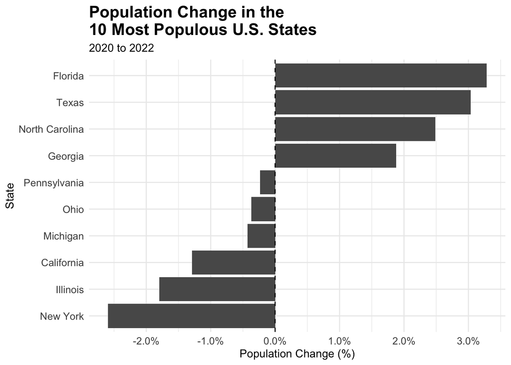

```r
ggplot(
  population_change,
  aes(
    x = percent_change,
    y = reorder(state, percent_change)
  )
) +
  geom_col() +
  geom_vline(
    xintercept = 0,
    linetype = "dashed"
  ) +
  labs(
    title = "Population Change in the\n10 Most Populous U.S. States",
    subtitle = "2020 to 2022",
    x = "Population Change (%)",
    y = "State"
  ) +
  scale_x_continuous(
    labels = scales::label_number(
      accuracy = 0.1,
      suffix = "%"
    )
  ) +
  theme_minimal() +
  theme(
    plot.title = element_text(
      size = 16,
      face = "bold"
    ),
    plot.subtitle = element_text(
      size = 11
    ),
    axis.title = element_text(
      size = 11
    ),
    axis.text = element_text(
      size = 10
    )
  )
```

```r
population_summary <- population_change %>%
  select(
    state,
    population_change,
    percent_change,
    population_trend
  ) %>%
  mutate(
    percent_change = round(percent_change, 2)
  ) %>%
  arrange(desc(percent_change))

population_summary
```

```
# A tibble: 10 × 4
   state          population_change percent_change population_trend
   <chr>                      <dbl>          <dbl> <chr>
 1 Florida                   706597           3.28 Population Gain
 2 Texas                     884144           3.03 Population Gain
 3 North Carolina            259559           2.49 Population Gain
 4 Georgia                   200939           1.88 Population Gain
 5 Pennsylvania              -30681          -0.24 Population Loss
 6 Ohio                      -43316          -0.37 Population Loss
 7 Michigan                  -43212          -0.43 Population Loss
 8 California               -508903          -1.29 Population Loss
 9 Illinois                 -230513          -1.8  Population Loss
10 New York                 -524079          -2.59 Population Loss
```

### Interpretation

From 2020 to 2022, four of the 10 states experienced population growth, while six experienced population loss. Florida had the largest percentage increase at approximately 3.28%, followed by Texas at 3.03%, North Carolina at 2.49%, and Georgia at 1.88%. New York experienced the largest percentage decline at approximately 2.59%, followed by Illinois at 1.80% and California at 1.29%. In terms of the number of residents, Texas had the largest population gain with approximately 884,144 additional residents, while New York had the largest population loss with approximately 524,079 fewer residents.

## Dataset 3 | World Bank life Expectancy

```r
life_url <- "https://raw.githubusercontent.com/yeimiperez14/Data_607/refs/heads/main/Project%202/Life_Expectancy_API_SP.DYN.LE00.IN_DS2_en_csv_v2_460061.csv"

life_raw <- read_csv(
  life_url,
  skip = 4
)
```

The third dataset contains life expectancy at birth data from the World Bank for countries and regions beginning in 1960. The original dataset is in wide format because each year is stored in a separate column.

The goal of this analysis is to transform the dataset into a tidy long format with separate variables for country, year, and life expectancy. I will then compare changes in life expectancy between Bangladesh and the United States and examine whether the life expectancy gapbetween the two countries has increased or decreased over time. The original dataset was obtained from other student, Ummay Rukiya, on 5A discussion and was saved as a CSV file on my github in its original wide format: [https://github.com/yeimiperez14/Data_607/tree/main/Project%202.](https://github.com/yeimiperez14/Data_607/tree/main/Project%202)

### Data structure before tidying

```r
names(life_raw)
```

```
 [1] "Country Name"   "Country Code"   "Indicator Name" "Indicator Code"
 [5] "1960"           "1961"           "1962"           "1963"
 [9] "1964"           "1965"           "1966"           "1967"
[13] "1968"           "1969"           "1970"           "1971"
[17] "1972"           "1973"           "1974"           "1975"
[21] "1976"           "1977"           "1978"           "1979"
[25] "1980"           "1981"           "1982"           "1983"
[29] "1984"           "1985"           "1986"           "1987"
[33] "1988"           "1989"           "1990"           "1991"
[37] "1992"           "1993"           "1994"           "1995"
[41] "1996"           "1997"           "1998"           "1999"
[45] "2000"           "2001"           "2002"           "2003"
[49] "2004"           "2005"           "2006"           "2007"
[53] "2008"           "2009"           "2010"           "2011"
[57] "2012"           "2013"           "2014"           "2015"
[61] "2016"           "2017"           "2018"           "2019"
[65] "2020"           "2021"           "2022"           "2023"
[69] "2024"           "2025"           "...71"
```

```r
dim(life_raw)
```

```
[1] 265  71
```

```r
names(life_raw)
```

```
 [1] "Country Name"   "Country Code"   "Indicator Name" "Indicator Code"
 [5] "1960"           "1961"           "1962"           "1963"
 [9] "1964"           "1965"           "1966"           "1967"
[13] "1968"           "1969"           "1970"           "1971"
[17] "1972"           "1973"           "1974"           "1975"
[21] "1976"           "1977"           "1978"           "1979"
[25] "1980"           "1981"           "1982"           "1983"
[29] "1984"           "1985"           "1986"           "1987"
[33] "1988"           "1989"           "1990"           "1991"
[37] "1992"           "1993"           "1994"           "1995"
[41] "1996"           "1997"           "1998"           "1999"
[45] "2000"           "2001"           "2002"           "2003"
[49] "2004"           "2005"           "2006"           "2007"
[53] "2008"           "2009"           "2010"           "2011"
[57] "2012"           "2013"           "2014"           "2015"
[61] "2016"           "2017"           "2018"           "2019"
[65] "2020"           "2021"           "2022"           "2023"
[69] "2024"           "2025"           "...71"
```

```r
head(life_raw)
```

```
# A tibble: 6 × 71
  `Country Name`  `Country Code` `Indicator Name` `Indicator Code` `1960` `1961`
  <chr>           <chr>          <chr>            <chr>             <dbl>  <dbl>
1 Aruba           ABW            Life expectancy… SP.DYN.LE00.IN     64.0   64.2
2 Africa Eastern… AFE            Life expectancy… SP.DYN.LE00.IN     44.2   44.5
3 Afghanistan     AFG            Life expectancy… SP.DYN.LE00.IN     32.8   33.3
4 Africa Western… AFW            Life expectancy… SP.DYN.LE00.IN     37.8   38.1
5 Angola          AGO            Life expectancy… SP.DYN.LE00.IN     37.9   36.9
6 Albania         ALB            Life expectancy… SP.DYN.LE00.IN     56.4   57.5
# ℹ 65 more variables: `1962` <dbl>, `1963` <dbl>, `1964` <dbl>, `1965` <dbl>,
#   `1966` <dbl>, `1967` <dbl>, `1968` <dbl>, `1969` <dbl>, `1970` <dbl>,
#   `1971` <dbl>, `1972` <dbl>, `1973` <dbl>, `1974` <dbl>, `1975` <dbl>,
#   `1976` <dbl>, `1977` <dbl>, `1978` <dbl>, `1979` <dbl>, `1980` <dbl>,
#   `1981` <dbl>, `1982` <dbl>, `1983` <dbl>, `1984` <dbl>, `1985` <dbl>,
#   `1986` <dbl>, `1987` <dbl>, `1988` <dbl>, `1989` <dbl>, `1990` <dbl>,
#   `1991` <dbl>, `1992` <dbl>, `1993` <dbl>, `1994` <dbl>, `1995` <dbl>, …
```

```r
glimpse(life_raw)
```

```
Rows: 265
Columns: 71
$ `Country Name`   <chr> "Aruba", "Africa Eastern and Southern", "Afghanistan"…
$ `Country Code`   <chr> "ABW", "AFE", "AFG", "AFW", "AGO", "ALB", "AND", "ARB…
$ `Indicator Name` <chr> "Life expectancy at birth, total (years)", "Life expe…
$ `Indicator Code` <chr> "SP.DYN.LE00.IN", "SP.DYN.LE00.IN", "SP.DYN.LE00.IN",…
$ `1960`           <dbl> 64.04900, 44.16966, 32.79900, 37.77964, 37.93300, 56.…
$ `1961`           <dbl> 64.21500, 44.46884, 33.29100, 38.05897, 36.90200, 57.…
$ `1962`           <dbl> 64.60200, 44.87789, 33.75700, 38.68179, 37.16800, 58.…
$ `1963`           <dbl> 64.94400, 45.16058, 34.20100, 38.93692, 37.41900, 59.…
$ `1964`           <dbl> 65.30300, 45.53570, 34.67300, 39.19438, 37.70400, 60.…
$ `1965`           <dbl> 65.61500, 45.77072, 35.12400, 39.47888, 37.96800, 61.…
$ `1966`           <dbl> 66.12600, 45.76573, 35.58300, 39.71703, 38.25800, 62.…
$ `1967`           <dbl> 66.38500, 46.44075, 36.04200, 39.52491, 38.61600, 62.…
$ `1968`           <dbl> 66.74400, 46.73863, 36.51000, 40.25261, 38.96800, 63.…
```

[output cut: 58 more lines]

### Transformation steps

```r
life_clean <- life_raw %>%
  select(-where(~ all(is.na(.))))

dim(life_clean)
```

```
[1] 265  69
```

`all(is.na(.))` checks whether every value in a column is missing. `select(-where(...))` removes any completely empty columns. I removed any completely empty columns because they contained no information that could be used in the analysis. No country observations were removed during this step.

```r
life_long <- life_clean %>%
  pivot_longer(
    cols = matches("^\\d{4}$"),
    names_to = "year",
    values_to = "life_expectancy"
  )

head(life_long)
```

```
# A tibble: 6 × 6
  `Country Name` `Country Code` `Indicator Name`          `Indicator Code` year
  <chr>          <chr>          <chr>                     <chr>            <chr>
1 Aruba          ABW            Life expectancy at birth… SP.DYN.LE00.IN   1960
2 Aruba          ABW            Life expectancy at birth… SP.DYN.LE00.IN   1961
3 Aruba          ABW            Life expectancy at birth… SP.DYN.LE00.IN   1962
4 Aruba          ABW            Life expectancy at birth… SP.DYN.LE00.IN   1963
5 Aruba          ABW            Life expectancy at birth… SP.DYN.LE00.IN   1964
6 Aruba          ABW            Life expectancy at birth… SP.DYN.LE00.IN   1965
# ℹ 1 more variable: life_expectancy <dbl>
```

matches(“^\\d{4}$”) selects column names containing exactly four digits, then `pivot_longer()` moves those years into one `year` column and puts the corresponding values into one `life_expectancy` column.

```r
life_tidy <- life_long %>%
  rename(
    country = `Country Name`,
    country_code = `Country Code`,
    indicator = `Indicator Name`,
    indicator_code = `Indicator Code`
  ) %>%
  mutate(
    year = as.integer(year)
  )

glimpse(life_tidy)
```

```
Rows: 17,225
Columns: 6
$ country         <chr> "Aruba", "Aruba", "Aruba", "Aruba", "Aruba", "Aruba", …
$ country_code    <chr> "ABW", "ABW", "ABW", "ABW", "ABW", "ABW", "ABW", "ABW"…
$ indicator       <chr> "Life expectancy at birth, total (years)", "Life expec…
$ indicator_code  <chr> "SP.DYN.LE00.IN", "SP.DYN.LE00.IN", "SP.DYN.LE00.IN", …
$ year            <int> 1960, 1961, 1962, 1963, 1964, 1965, 1966, 1967, 1968, …
$ life_expectancy <dbl> 64.049, 64.215, 64.602, 64.944, 65.303, 65.615, 66.126…
```

We now have one variable per column and one observation per row.

### Addressing missing values

```r
colSums(is.na(life_tidy))
```

```
        country    country_code       indicator  indicator_code            year
              0               0               0               0               0
life_expectancy
             99
```

```r
life_tidy %>%
  filter(
    country %in% c("Bangladesh", "United States")
  ) %>%
  summarise(
    total_rows = n(),
    missing_life_expectancy = sum(is.na(life_expectancy)),
    first_year_available = min(year[!is.na(life_expectancy)]),
    last_year_available = max(year[!is.na(life_expectancy)])
  )
```

```
# A tibble: 1 × 4
  total_rows missing_life_expectancy first_year_available last_year_available
       <int>                   <int>                <int>               <int>
1        130                       0                 1960                2024
```

Bangladesh and the United States both have complete life-expectancy data from 1960 through 2024. You have 130 total observations because there are 65 years for each of the two countries: 65 years × 2 countries = 130 observations with no missing life expectancy values.

### Analysis

```r
life_comparison <- life_tidy %>%
  filter(
    country %in% c("Bangladesh", "United States")
  ) %>%
  select(
    country,
    year,
    life_expectancy
  )

life_comparison
```

```
# A tibble: 130 × 3
   country     year life_expectancy
   <chr>      <int>           <dbl>
 1 Bangladesh  1960            44.0
 2 Bangladesh  1961            44.9
 3 Bangladesh  1962            45.8
 4 Bangladesh  1963            45.7
 5 Bangladesh  1964            46.8
 6 Bangladesh  1965            46.0
 7 Bangladesh  1966            47.6
 8 Bangladesh  1967            48.1
 9 Bangladesh  1968            48.4
10 Bangladesh  1969            48.7
# ℹ 120 more rows
```

Here I filtered the tidy dataset to our two countries.

### Visualization

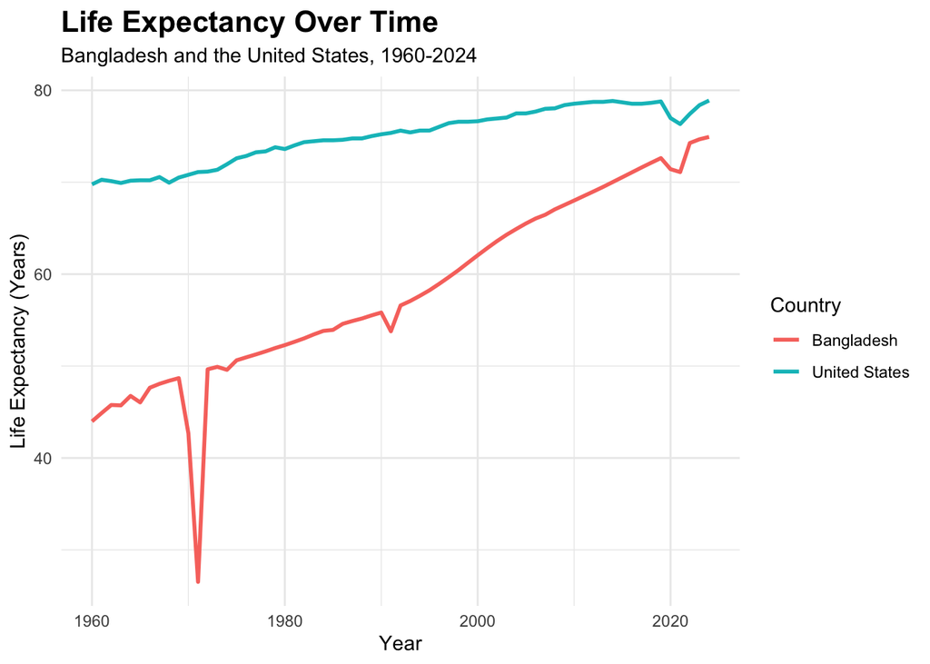

```r
ggplot(
  life_comparison,
  aes(
    x = year,
    y = life_expectancy,
    color = country
  )
) +
  geom_line(linewidth = 1) +
  labs(
    title = "Life Expectancy Over Time",
    subtitle = "Bangladesh and the United States, 1960-2024",
    x = "Year",
    y = "Life Expectancy (Years)",
    color = "Country"
  ) +
  theme_minimal() +
  theme(
    plot.title = element_text(
      size = 16,
      face = "bold"
    ),
    plot.subtitle = element_text(
      size = 11
    )
  )
```

```r
life_gap <- life_comparison %>%
  pivot_wider(
    names_from = country,
    values_from = life_expectancy
  ) %>%
  mutate(
    gap = `United States` - Bangladesh
  )

life_gap
```

```
# A tibble: 65 × 4
    year Bangladesh `United States`   gap
   <int>      <dbl>           <dbl> <dbl>
 1  1960       44.0            69.8  25.8
 2  1961       44.9            70.3  25.4
 3  1962       45.8            70.1  24.4
 4  1963       45.7            69.9  24.2
 5  1964       46.8            70.2  23.4
 6  1965       46.0            70.2  24.2
 7  1966       47.6            70.2  22.6
 8  1967       48.1            70.6  22.5
 9  1968       48.4            70.0  21.6
10  1969       48.7            70.5  21.8
# ℹ 55 more rows
```

The `gap` variable tells us how many years higher U.S. life expectancy was than Bangladesh’s in each year.

```r
life_gap %>%
  filter(year %in% c(1960, 2024))
```

```
# A tibble: 2 × 4
   year Bangladesh `United States`   gap
  <int>      <dbl>           <dbl> <dbl>
1  1960       44.0            69.8 25.8
2  2024       74.9            78.9  3.96
```

Here I compared the beginning and end values for 1960 and 2024. 1960: Bangladesh = 43.98 years; U.S. = 69.77 years → gap = 25.79 years. 2024: Bangladesh = 74.93 years; U.S. = 78.89 years → gap = 3.96 years. Therefore, the gap narrowed by about 21.83 years.

```r
gap_change <- life_gap %>%
  filter(year %in% c(1960, 2024)) %>%
  summarise(
    gap_1960 = gap[year == 1960],
    gap_2024 = gap[year == 2024],
    decrease_in_gap = gap_1960 - gap_2024
  )

gap_change
```

```
# A tibble: 1 × 3
  gap_1960 gap_2024 decrease_in_gap
     <dbl>    <dbl>           <dbl>
1     25.8     3.96            21.8
```

Here I calculated how much the gap decreased, the life expectancy between the two countries narrowed by approximately 21.83 years.

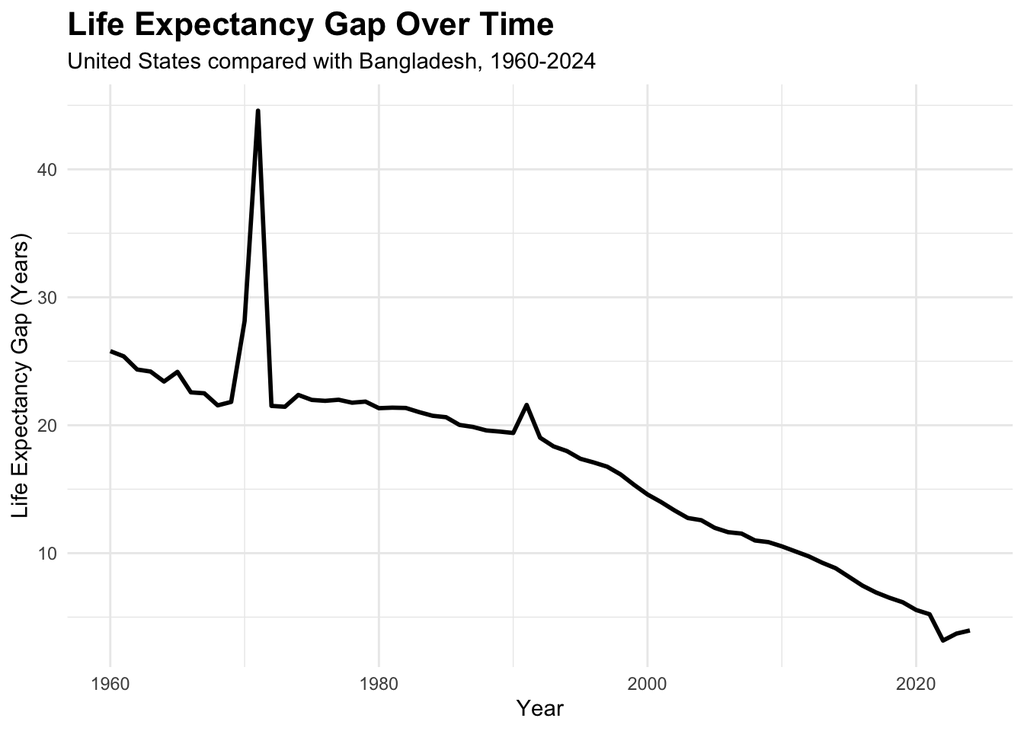

```r
ggplot(
  life_gap,
  aes(
    x = year,
    y = gap
  )
) +
  geom_line(linewidth = 1) +
  labs(
    title = "Life Expectancy Gap Over Time",
    subtitle = "United States compared with Bangladesh, 1960-2024",
    x = "Year",
    y = "Life Expectancy Gap (Years)"
  ) +
  theme_minimal() +
  theme(
    plot.title = element_text(
      size = 16,
      face = "bold"
    ),
    plot.subtitle = element_text(
      size = 11
    )
  )
```

Each point along the line represents the difference between U.S. and Bangladesh life expectancy for that year. A declining line indicates that the difference between the two countries is becoming smaller.

### Interpretation

The analysis shows that life expectancy increased in both Bangladesh and the United States between 1960 and 2024, but Bangladesh experienced a much larger improvement. In 1960, life expectancy was approximately 43.98 years in Bangladesh compared with 69.77 years in the United States, a gap of about 25.79 years. By 2024, life expectancy had increased to approximately 74.93 years in Bangladesh and 78.89 years in the United States. The gap decreased to approximately 3.96 years, meaning the difference between the two countries narrowed by about 21.83 years over the period. The results show that Bangladesh moved substantially closer to the United States in life expectancy.

# Conclusion

This project demonstrated how three different wide-format datasets can be transformed into tidy formats using `tidyr` and `dplyr` and then used for analysis. The tuition data showed an overall increase in tuition over time, with Hawaii experiencing the largest increase among the states analyzed. The Census population data showed different population trends from 2020 to 2022, with Florida having the largest percentage increase and New York having the largest percentage decrease among the 10 states. Finally, the World Bank life expectancy data showed that although life expectancy increased in both Bangladesh and the United States, the gap between the two countries decreased substantially from about 25.79 years in 1960 to 3.96 years in 2024. Overall, tidying each dataset made it easier to calculate changes, compare groups, identify trends, and create clear visualizations.